# Week03_NYPD Shooting Incident Data Report

2022-07-03

# NYPD Shooting Incident Data

The data in this report is based on the “NYPD Shooting Incident Data (Historic)” in DATA.GOV. This data include the list of every shooting incident that occurred in NYC going back to 2006 through the end of the previous calendar year. “https://catalog.data.gov/dataset?q=NYPD+Shooting+Incident+Data+%28Historic%29&sort=views_recent+desc&ext_location=&ext_bbox=&ext_prev_extent=-150.46875%2C-80.17871349622823%2C151.875%2C80.17871349622823”

## Inport data and read csv file. Then create new column that have yyyymm data.plot()

```r
## Get NYPD Shooting Incident Data
csv_url <- "https://data.cityofnewyork.us/api/views/833y-fsy8/rows.csv?accessType=DOWNLOAD"
csv_data <- read.csv(csv_url)
original_data <- csv_data
original_data$yyyymm <- format(mdy(original_data$OCCUR_DATE), "%Y-%m")
original_data$yyyy <- format(mdy(original_data$OCCUR_DATE), "%Y")
```

## Data Processing

```r
group_by_month <- group_by(original_data, yyyymm)
group_by_month_boro <- group_by(original_data, BORO, yyyymm)
summarise_month <- summarise(group_by_month, count=n_distinct(INCIDENT_KEY))
summarise_month_boro <- summarise(group_by_month_boro, count=n_distinct(INCIDENT_KEY))
group_by_year <- group_by(original_data, yyyy)
group_by_year_boro <- group_by(original_data, BORO, yyyy)
summarise_year <- summarise(group_by_year, count=n_distinct(INCIDENT_KEY))
summarise_year_boro <- summarise(group_by_year_boro, count=n_distinct(INCIDENT_KEY))
```

## Capture trends in the number of incident per BORO

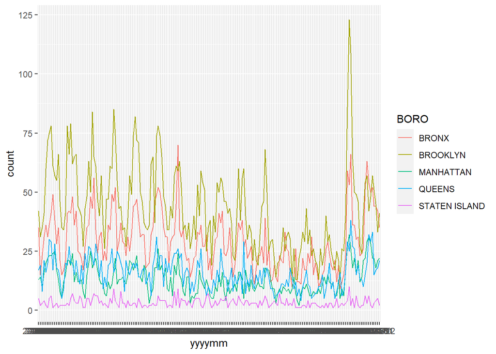

```r
g_BORO <- ggplot(summarise_month_boro, aes(x=yyyymm, y=count, group=BORO)) + geom_line(aes(colour = BORO))
plot(g_BORO)
```

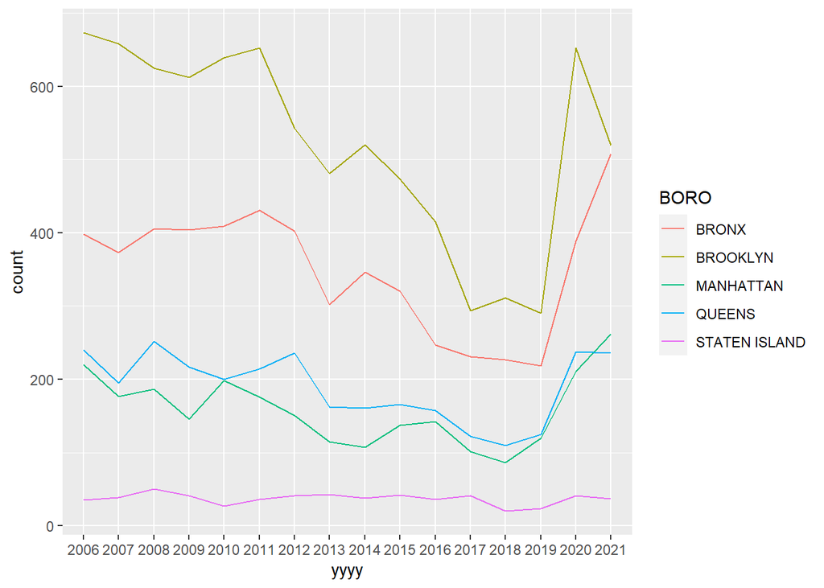

```r
g_BORO_year <- ggplot(summarise_year_boro, aes(x=yyyy, y=count, group=BORO)) + geom_line(aes(colour = BORO))
plot(g_BORO_year)
```

Aggregating the number of cases, all regions have fewer cases per 2017~2019.However, it can be seen that the number of cases has been increasing since 2020. This data alone does not allow us to analyze this factor, so some other information is needed.

The graph also shows that even during the course of a year, there is a tendency every year for the number of cases to be higher around May-August. As an example, the data for BRONX for 2020 and 2021 only is shown below.

## Visualize 2020/2021 data for BRONX

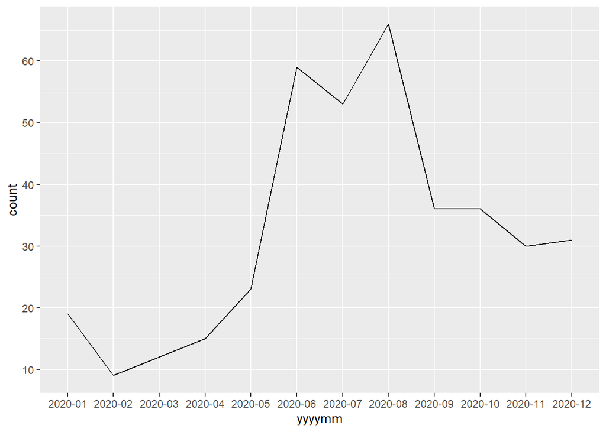

```r
BRONX_2020 <- summarise_month_boro[summarise_month_boro$BORO=="BRONX" & summarise_month_boro$yyyymm>"2019-12" & summarise_month_boro$yyyymm<="2020-12",]
g_BRONX_2020 <- ggplot(BRONX_2020, aes(x=yyyymm, y=count, group=1)) + geom_line()

BRONX_2021 <- summarise_month_boro[summarise_month_boro$BORO=="BRONX" & summarise_month_boro$yyyymm>"2020-12",]
g_BRONX_2021 <- ggplot(BRONX_2021, aes(x=yyyymm, y=count, group=1)) + geom_line()

plot(g_BRONX_2020)
```

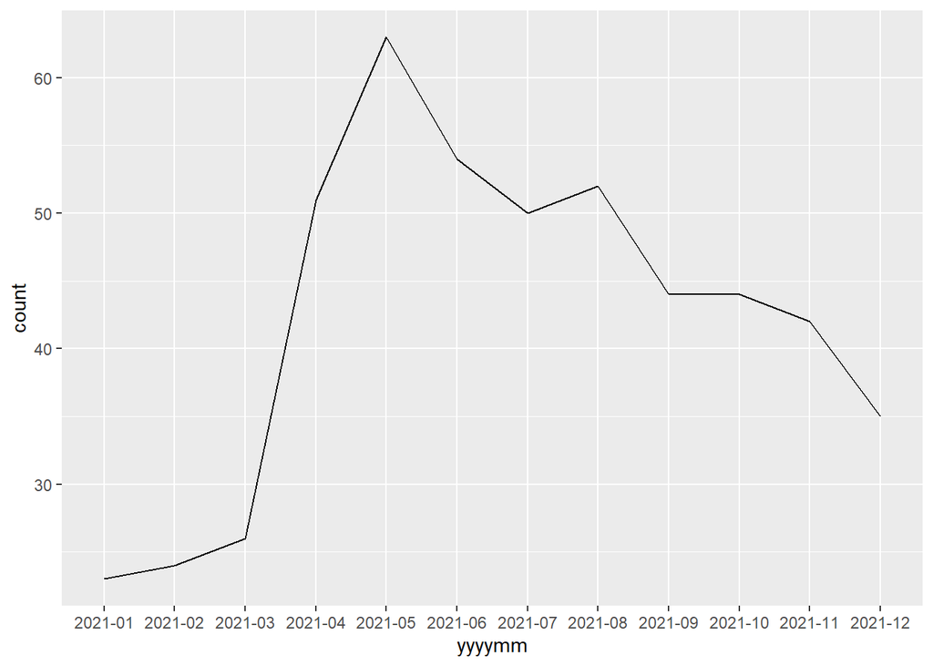

```r
plot(g_BRONX_2021)
```

Next, we would like to create a forecasting model for the annual number of incident based on the number of incident per year to date.

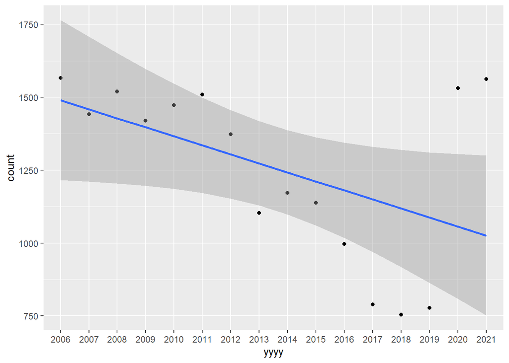

```r
g_yearly_data <- ggplot(summarise_year, aes(x=yyyy, y=count, group=1)) + geom_point() + geom_smooth(method="lm")
plot(g_yearly_data)
```

In this model, it appears that the number of future annual incidents will continue to decline. However, the most recent years, 2020 and 2021, clearly show an increase, and unless there is a reason for the increase in 2020 and 2021 due to special circumstances, etc., it would be difficult to predict the number of cases after 2022 with this model.

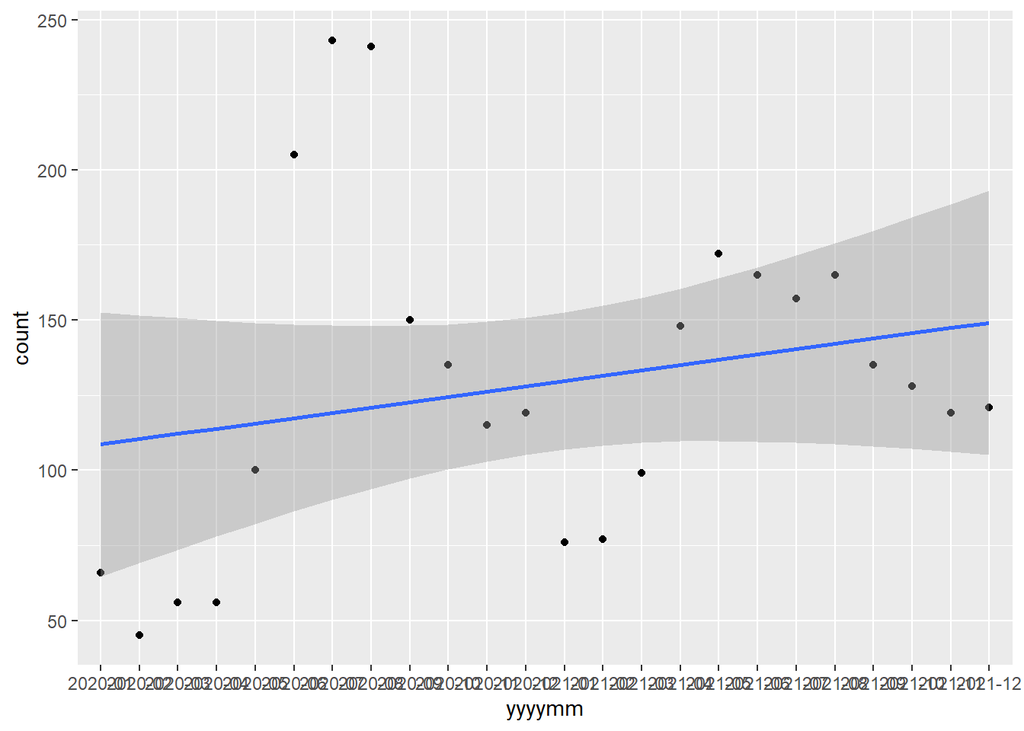

```r
data_2020_2021 <- summarise_month[summarise_month$yyyymm>"2019-12" & summarise_month$yyyymm<="2021-12",]
g_2020_2021 <- ggplot(data_2020_2021, aes(x=yyyymm, y=count, group=1)) + geom_point() + geom_smooth(method="lm")
plot(g_2020_2021)
```

Modeling with the most recent 2020 and 2021 data suggests that the number of incident will continue to increase slightly.